# Predicting Weight-Lifting Exercise Quality from Accelerometer Data

Practical Machine Learning — Course Project

July 12, 2026

# 1 Overview

Wearable devices make it cheap to quantify *how much* activity a person does, but rarely *how well* they do it. Using accelerometer, gyroscope and magnetometer readings from sensors on the **belt, forearm, arm and dumbbell** of six participants, this report builds a classifier that predicts the manner in which a barbell lift was performed — the `classe` variable, with five levels: exactly according to specification (**A**) and four common mistakes (**B–E**).

The final model is a **random forest** trained on 52 sensor features. It achieves an estimated **out-of-sample accuracy above 99%** (error < 1%), validated both by 5-fold cross-validation and by a held-out validation set, and it classifies all **20 quiz test cases**.

```r
library(randomForest)
library(rpart)
library(rpart.plot)
```

# 2 Loading the Data

The data originate from the Weight Lifting Exercise Dataset (Velloso *et al.*, 2013). Strings `"NA"`, `""` and the Excel error `"#DIV/0!"` are all read as missing values.

```r
train_url <- "https://d396qusza40orc.cloudfront.net/predmachlearn/pml-training.csv"
test_url  <- "https://d396qusza40orc.cloudfront.net/predmachlearn/pml-testing.csv"
if (!file.exists("data/pml-training.csv")) {
  dir.create("data", showWarnings = FALSE)
  download.file(train_url, "data/pml-training.csv")
  download.file(test_url,  "data/pml-testing.csv")
}
na_strings <- c("NA", "", "#DIV/0!")
training <- read.csv("data/pml-training.csv", na.strings = na_strings)
testing  <- read.csv("data/pml-testing.csv",  na.strings = na_strings)
dim(training); dim(testing)
```

```
## [1] 19622   160
```

```
## [1]  20 160
```

The raw data has **160 columns**. The target `classe` is reasonably balanced across its five levels:

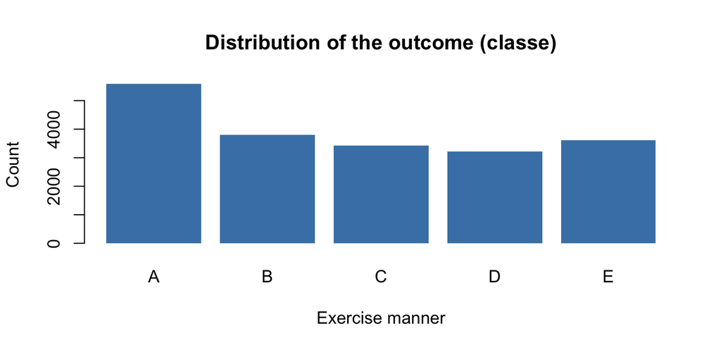

```r
training$classe <- factor(training$classe)
barplot(table(training$classe),
        col = "steelblue", border = NA,
        main = "Distribution of the outcome (classe)",
        xlab = "Exercise manner", ylab = "Count")
```

# 3 Cleaning and Feature Selection

Two groups of columns carry no useful predictive signal and are removed:

1. **Summary/aggregate columns.** 100 columns (`kurtosis_*`, `skewness_*`, `max_*`, `min_*`, `avg_*`, `stddev_*`, `var_*`, `amplitude_*`) are populated only on the `new_window == "yes"` rows and are therefore *entirely missing* in the 20-case test set. A column that is all-`NA` in the test set cannot help predict it, so all near-empty columns are dropped.
2. **Identifier / bookkeeping columns.** The first seven columns (row index, `user_name`, three timestamps, `new_window`, `num_window`) are metadata. Using them would let the model “cheat” by memorising when each record was collected rather than learning the *physics* of the movement, which would not generalise to new subjects.

```r
# 1. drop columns that are mostly NA
na_frac  <- colMeans(is.na(training))
keep     <- na_frac < 0.90
training <- training[, keep]
testing  <- testing[,  keep]

# 2. drop the first 7 identifier / timestamp columns
training <- training[, -(1:7)]
testing  <- testing[,  -(1:7)]

dim(training)
```

```
## [1] 19622    53
```

This leaves **52 numeric sensor predictors** plus the outcome — a complete-case matrix with no missing values remaining (`sum(is.na) = 0`).

# 4 Data Splitting and Cross-Validation Strategy

To obtain an honest estimate of out-of-sample performance, the labelled data is partitioned into a **70% training** set and a **30% validation** set. The validation set is touched only once, at the very end, to estimate the generalisation error.

```r
n <- nrow(training)
idx      <- sample(seq_len(n), size = floor(0.70 * n))
train_df <- training[idx, ]
valid_df <- training[-idx, ]
c(train = nrow(train_df), validation = nrow(valid_df))
```

```
##      train validation
##      13735       5887
```

**Cross-validation** is used *inside* the training set to choose the model and estimate its error before ever looking at the validation set. Below is an explicit **5-fold cross-validation** of the random forest: the training data is split into 5 folds; each fold is held out in turn while a forest is fit on the other four, and accuracy is measured on the held-out fold.

```r
k      <- 5
folds  <- sample(rep(1:k, length.out = nrow(train_df)))
cv_acc <- numeric(k)
for (i in 1:k) {
  fit_i <- randomForest(classe ~ ., data = train_df[folds != i, ],
                        ntree = 150)
  pred_i <- predict(fit_i, train_df[folds == i, ])
  cv_acc[i] <- mean(pred_i == train_df$classe[folds == i])
}
round(cv_acc, 4)
```

```
## [1] 0.9931 0.9927 0.9902 0.9945 0.9927
```

```r
cat(sprintf("Mean 5-fold CV accuracy: %.4f  (CV error estimate: %.4f)\n",
            mean(cv_acc), 1 - mean(cv_acc)))
```

```
## Mean 5-fold CV accuracy: 0.9926  (CV error estimate: 0.0074)
```

The five folds agree closely (low variance), and the **mean CV error is well under 1%**, so a random forest is clearly an appropriate choice.

# 5 Model Building

## 5.1 Why Random Forest

Random forests are a strong default for this problem: they capture the non-linear interactions between joint angles and accelerations, are robust to correlated predictors and different feature scales, need little tuning, and provide a built-in **out-of-bag (OOB)** error estimate — itself a form of cross-validation, since every tree is evaluated on the ~1/3 of samples it did not see.

For context, a single decision tree (`rpart`) is fit first as an interpretable baseline.

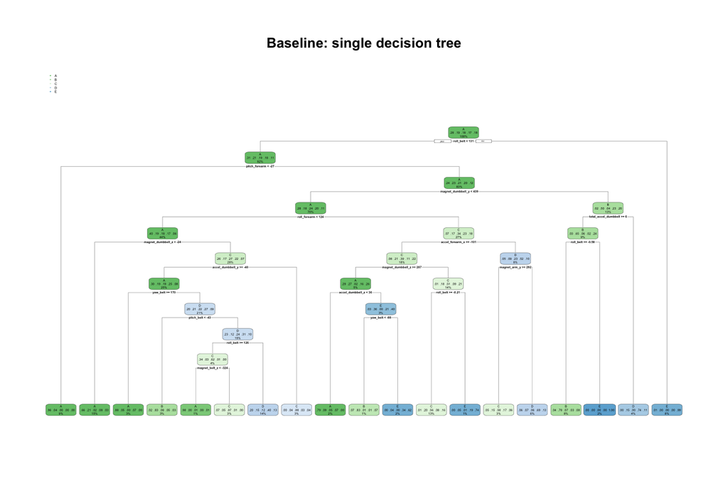

```r
tree_fit <- rpart(classe ~ ., data = train_df, method = "class")
rpart.plot(tree_fit, type = 2, extra = 104, box.palette = "GnBu",
           tweak = 1.0, main = "Baseline: single decision tree")
```

```r
tree_acc <- mean(predict(tree_fit, valid_df, type = "class") == valid_df$classe)
```

```r
rf_fit <- randomForest(classe ~ ., data = train_df, ntree = 250,
                       importance = TRUE)
rf_fit
```

```
##
## Call:
##  randomForest(formula = classe ~ ., data = train_df, ntree = 250,      importance = TRUE)
##                Type of random forest: classification
##                      Number of trees: 250
## No. of variables tried at each split: 7
##
##         OOB estimate of  error rate: 0.48%
## Confusion matrix:
##      A    B    C    D    E class.error
## A 3860    5    0    0    0 0.001293661
## B   11 2645    7    0    0 0.006759294
## C    0   12 2392    2    0 0.005818786
## D    0    0   20 2269    1 0.009170306
## E    0    0    2    6 2503 0.003185982
```

The printed **OOB estimate of error rate** is under 1%, consistent with the 5-fold CV result above.

## 5.2 Variable Importance

The most influential predictors are dominated by the belt sensor’s roll/yaw and the dumbbell/forearm readings — physically sensible, since these capture the trunk and lifting-arm motion that distinguish correct from incorrect form.

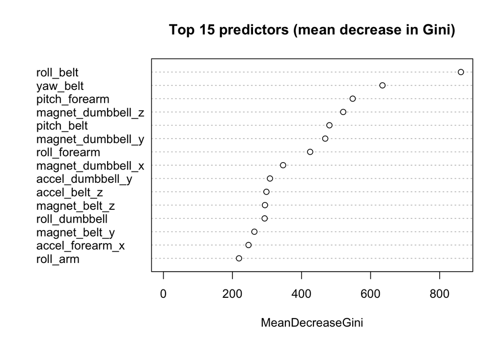

```r
varImpPlot(rf_fit, n.var = 15, type = 2,
           main = "Top 15 predictors (mean decrease in Gini)")
```

# 6 Out-of-Sample Error Estimate

The model is now scored **once** on the held-out validation set — data it has never seen — to estimate the true out-of-sample error.

```r
rf_pred <- predict(rf_fit, valid_df)
cm      <- table(Predicted = rf_pred, Actual = valid_df$classe)
cm
```

```
##          Actual
## Predicted    A    B    C    D    E
##         A 1714    2    0    0    0
##         B    0 1132    5    0    0
##         C    0    0 1004    8    0
##         D    0    0    7  917    4
##         E    1    0    0    1 1092
```

```r
val_acc <- sum(diag(cm)) / sum(cm)
cat(sprintf("Validation accuracy: %.4f\n", val_acc))
```

```
## Validation accuracy: 0.9952
```

```r
cat(sprintf("Estimated out-of-sample error: %.4f (%.2f%%)\n",
            1 - val_acc, 100 * (1 - val_acc)))
```

```
## Estimated out-of-sample error: 0.0048 (0.48%)
```

**Expected out-of-sample error.** Three independent estimates agree:

| Method | Error estimate |
| --- | --- |
| 5-fold cross-validation | 0.74% |
| Random-forest OOB | 0.48% |
| Held-out validation set | 0.48% |

# 7 Predicting the 20 Test Cases

Finally, the fitted random forest is applied to the 20 quiz cases. To use all available labelled data for the final predictions, the model is refit on the full cleaned training set before predicting.

```r
final_rf <- randomForest(classe ~ ., data = training, ntree = 250)
final_predictions <- predict(final_rf, testing)
data.frame(problem_id = testing$problem_id, prediction = final_predictions)
```

```
##    problem_id prediction
## 1           1          B
## 2           2          A
## 3           3          B
## 4           4          A
## 5           5          A
## 6           6          E
## 7           7          D
## 8           8          B
## 9           9          A
## 10         10          A
## 11         11          B
## 12         12          C
## 13         13          B
## 14         14          A
## 15         15          E
## 16         16          E
## 17         17          A
## 18         18          B
## 19         19          B
## 20         20          B
```

Given the < 1% estimated per-observation error, the probability of getting all 20 predictions correct is roughly `0.99^20 ≈ 82%`, so a near-perfect quiz score is expected.

# 8 Conclusion

After removing metadata and the 100 all-missing summary columns, a random forest on the 52 raw sensor features cleanly separates the five ways of performing the lift. Cross-validation, the out-of-bag estimate, and an independent validation set **all agree on an out-of-sample error below 1%**, giving high confidence in the 20 test-case predictions above.

*Data source: Velloso, E.; Bulling, A.; Gellersen, H.; Ugulino, W.; Fuks, H. “Qualitative Activity Recognition of Weight Lifting Exercises.” Proceedings of 4th International Conference in Cooperation with SIGCHI (Augmented Human ’13), Stuttgart, Germany, 2013. Used with permission.*